# Data Science Challenge

Samuel Huerga

September 27th, 2019

## Data Science Challenge

### Part 1: Experiment design

#### Background

In 2011 AirBnB ran some experiments which showed that when a property featured professional photography, users were much more likely to trust the property and consequently make a booking. So, AirBnB a launched [free professional photography service](https://www.airbnb.com/professional_photography) for all hosts. From inside the listing page, hosts were able to click a link to view more about the service, request a professional photographer, and subsequently (after the photo shoot) have their property profile updated with professional photos.

The project initially proved to be a success:

- Guests were more likely to book a property that had professional photography
- Hosts were able to charge more for listings with professional photos

However, over time this also became a multimillion dollar operation and a challenge to manage across over 200 countries.

Fast forward to 2016, and some new developments have also helped with building trust:

- 2013: Launch of identity verification for hosts and guests
- 2014: Launch of double blind reviews (neither host nor guest can see the other’s review), ensuring more honest reviews of properties and hosts.
- 2015: Huge global PR lift for AirBnB, raising the profile of the company

An additional interesting development has also been the proliferation of smartphones with powerful and high-quality cameras (+apps) over the last few years, which has made it more possible for hosts to take good quality photos of their property. There is also the opinion that perhaps millennials have come to expect smartphone photos as the norm and are less likely to expect professional photography.

#### Challenge

Since the professional photography service consumes so many operational and financial resources, AirBnB management are unsure if they should continue. AirBnB management have asked the Data Science team to analyse the impact of the professional photography service in order to determine whether or not they should continue funding the service.

1. Provide full details about how you will run experiments to assess the impact of this service on both hosts and guests. How will you ensure that the experiments are valid and not biased?

##### Solution

Let’s peform an A/B test to analyse whether AirBnB should continue offering this service or not. To do so, we run an experiment consisting on comparing how booking rate varies if professional photos are shown instead of particular ones for the same apartments.

#### Considerations

We run an experiment to study the following test:

$$H_0 : \text{booking rate}_{standard} = \text{booking rate}_{professional} \\
H_A : \text{booking rate}_{standard} < \text{booking rate}_{professional}$$

We can proceed by offering the professional service to certain users. For the apartments whose owners agree to hire this service, two versions of the same page is displayed at random to the visitor: the control group will see old photos, and the experiment group will see new proesional photos for a certain period of time. The only change a user will see will be the pictures. Ranking, descriptions, reviews and page appearence will keep the same for both groups.

Some considerations about the experiment:

- In order to start with the experiment, we can try with only one city, and based on the results, expand our test to the rest of cities in the future. We can focus on a segment which has similar features and if the test is succesfull, rerun a broader test covering the rest of segments.
- However, in order to make our sample representative of reality, it would be recommendable to target all posible differences within this segment, in order to capture all posible variance of data. For example, considering different number of bedrooms, diverse sizes, and a broad range of prices and locations within the city.
- Duration of test would be ideally a week. With this, we can capture visits from weekdays and weekends, and make sure we do not introduce bias based on day of the week. For example, we could inform hosts who suscribes to professional photo service that new photos may take up to a week to be available for the rest of users (period in which we would perform our A/B test)
- Our test should be implemented in both web and mobile apps, to assure consistency of the test.

#### Unit of diversion

We want to track how many people who see one of our listings eventually book a reservation.

First, let’s think about which should be our unit of diversion, i.e, the information used in order to assign an user to either control or experiment group.

Here we have some options; we can diverse based on cookies, on IP addresses or on user ids. As an user may get connected in different devices (laptop, mobile, work PC…), splits based on cookies or IP addresses could possible show different versions of the same listing to the same user, so he would be in control and experiment group at the same time. Besides, as we want to keep track of bookings, and only a register and logged user can book, it makes sense that the unit of diversion that best suits this test be the user id.

#### Metric choice

We want to measure the proportion of visits that actually converts into a booking. In order to keep things simple and to avoid outliers, we will only count visits of logged users (our unit of diversion) and will only count one visit per user, regardless of how many times the same user has visited the page. In other words, we will only track unique users that have shown an interest on the property.

Our booking rate for a property will be:

$$\text{booking rate} = \frac{\text{number of bookings}}{\text{number of unique users}}$$

#### Sizing the experiment

We will run this test as a paired A/B test. That means that we will measure difference in booking rate for each apartment during a whole week. To size the experiment, we stablish a significance level (usually 95%), power (usually 80%), and the expected effect size, and we determine how big our samples should be.

For example, if we want a test with enough power to detect a small effect size, we would need 156 properties.

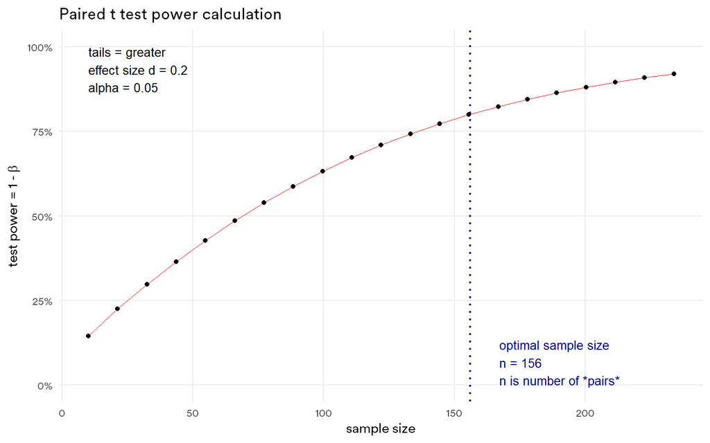

#### Testing

After having run our experiment for a week, we explore the results. First, we need to check that data collected are valid, that is, that all assumptions we made in design have been inherited to our samples. We run some sanity checks in order to determine if both samples have same distribution of other control variables (for example, demographics), as these differences could bias our conclusions.

If these assumptions are right, we can compare means with a t-test, and see if there is a statistically significant difference on booking rates.

#### Next steps

If we observe statistically significant change in booking rate of listings with professional photos, we can expand our testing to other cities and segments and observe the behaviour. Some socioeconomic factors may affect and we can find different results depending on the country.

Besides, in order to isolate seasonal impact on our data (holidays, summer…), we could rerun the experiment on different periods of the year.

### Part 2: Result analysis

#### Background

A ride hailing app currently assigns new incoming trips to the *closest* available vehicle. To compute such distance, the app currently computes haversine distance between the pickup point and each of the available vehicles. We refer to this distance as *linear*

However, the expected time to reach A from B in a city is not 100% defined by Haversine distance: Cities are known to be places where huge amount of transport infrastructure (roads, highways, bridges, tunnels) is deployed to increase capacity and reduce average travel time. Interestingly, this heavy investment in infrastructure also implies that bird distance does not work so well as proxy, so the isochrones for travel time from certain location drastically differ from the perfect circle defined by bird distance, as we can see in this example from CDMX where the blue area represents that it is reachable within a 10 min drive.

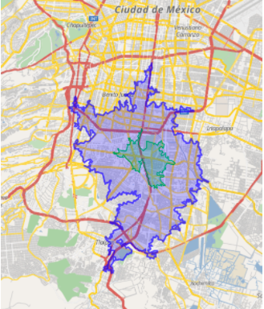

In addition to this, travel times can be drastically affected by traffic, accidents, road work…So that even if a driver is only 300m away, he might need to drive for 10 min because of road work in a bridge.

#### Proposal

In order to optimise operations, engineering team has suggested they could query an external real time maps API that not only has roads, but also knows realtime traffic information. We refer to this distance as *road* distance.

In principle this assigment is more efficient and should outperform *linear*. However, the queries to the maps API have a certain cost (per query) and increase the complexity and reliability of a critical system within the company. So Data Science team has designed an experiment to help engineering to decide

#### Experimental design

The designed expirement is very simple. For a period of 5 days, all trips in 3 cities (Bravos, Pentos and Volantis) have been randomly assigned using *linear* or *road* distance:

- Trips whose *trip_id* starts with digits 0-8 were assigned using *road* distance
- Trips whose *trip_id* starts with digits 9-f were assigned using *linear* distance

#### Data description

The collected data is available available in [this link](https://www.dropbox.com/s/e3j1pybfz5o3vq9/intervals_challenge.json.gz?dl=0). Each object represent a `vehicle_interval` that contains the following attributes:

- `type`: can be `going_to_pickup`, `waiting_for_rider` or `driving_to_destination`
- `trip_id`: uniquely identifies the trip
- `duration`: how long the interval last, in seconds
- `distance`: how far the vehicle moved in this interval, in meters
- `city_id`: either bravos, pentos and volantis
- `started_at`: when the interval started, UTC Time
- `vehicle_id`: uniquely identifies the vehicle
- `rider_id`: uniquely identifies the rider

#### Example

```
{
  "duration": 857,
  "distance": 5384,
  "started_at": 1475499600.287,
  "trip_id": "c00cee6963e0dc66e50e271239426914",
  "vehicle_id": "52d38cf1a3240d5cbdcf730f2d9a47d6",
  "city_id": "pentos",
  "type": "driving_to_destination"
}
```

#### Challenge

Try to answer the following questions

1. Should the company move towards *road* distance? What’s the max price it would make sense to pay per query? (make all the assumptions you need, and make them explicit)
2. How would you improve the experimental design? Would you collect any additional data?

#### Introduction

The aim of this analysis is perform an hypothesis test on each three cities in order to determine whether *road* distance is statistically better than *linear* distance in terms of some metric.

#### Data preprocessing

First of all, data has been cleaned. Column `started_at` has converted to UTC time in order to ease the analysis, and a new column `type_experiment` has been built from `trip_id`,indicating if trip has been assigned using *road* or *linear* distance.

Let’s perform an introductory exploratory analysis in order to evaluate quality of data. There are only 3 states, however, not all `trip_id` in our data has gone through these three states, mainly because extracted data could have captured some unfinished rides:

| number_disctint_states | number_trip_id |
| --- | --- |
| 1 | 4945 |
| 2 | 1042 |
| 3 | 52699 |

So we exclude these trips from our study.

#### Choosing a metric

In order to evaluate the performance of the distance chosen, we need to choose a metric that captures the essence of what we want to measure. We cannot choose `duration` as a metric, because it will likely depend on distance. If we want to assign the driver who is *closest* (according to *road* distance) to the rider, then we want the driver who will come fastest to him, even if this driver is further than others.

To compute speed, we divide `distance` by `duration`. As we may have very low duration (for example, there are 22 vehicle intervals of `type` `going_to_pickup` which has a duration of 0 seconds, and 1344 which has a duration of 10 seconds or less), maybe caused by a wrong behaviour of the driver, we need to set some restrictions on data we will use before analysing the problem.

#### Sanity checks: control variables

We need to check if it is legimit to compare between the two diferent groups of measures, *road* and *linear*.

To do so, we need to analyse if the split made in order to assign a distance is biased or not, comparing distributions across other control variables, regardless of the split. For example, imagine that *linear* distance has been assigned more on peak hours, and *road* has been assigned more during off-peak hours. This would probably lead to *road* speed is greater than *linear*, when it is not comparable.

We only have data for almost 32 hours (from 2016-10-03 13:00:00 to 2016-10-04 20:36:20). To study if distribution is comparable between the two groups, we can plot the number of rides per hour for each of groups, for the three cities:

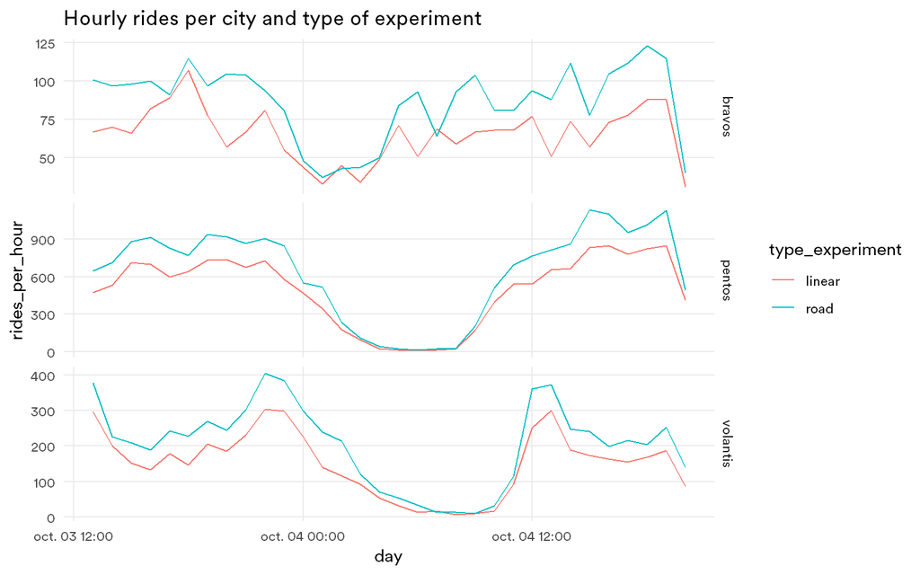

And we can see that, except for Bravos, distribution is almost identical. We can compute it numerically with correlation between *road* and *linear* hourly rides for every city:

| city_id | cor |
| --- | --- |
| bravos | 0.81 |
| pentos | 0.99 |
| volantis | 0.99 |

#### Exploratory Data Analysis

To see how well our metric is defined, we need to study `distance` and `duration` and make some assumptions on data.

Let’s begin with distance. We can see, for our three cities, how distance is distributed (axis has been truncated up to 5km):

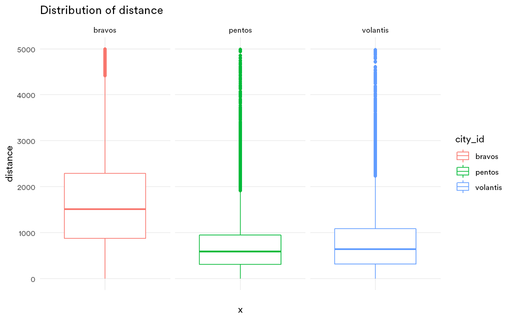

And we can compare distribution on splits:

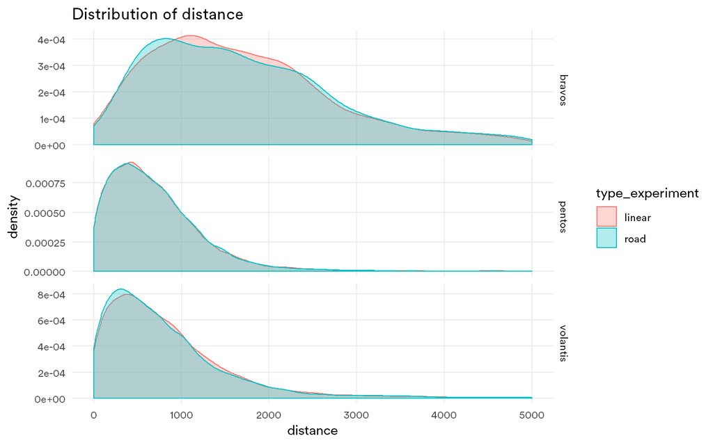

We can observe two main points: - Bravos drivers are further from riders than Pentos and Volantis (maybe because there are less cars in Bravos than in the others cities) - Distance distribution over `type_experiment` is similar.

If we scatter plot distance vs duration, we can observe this distribution, plus some outliers, that lies far beyond 5km:

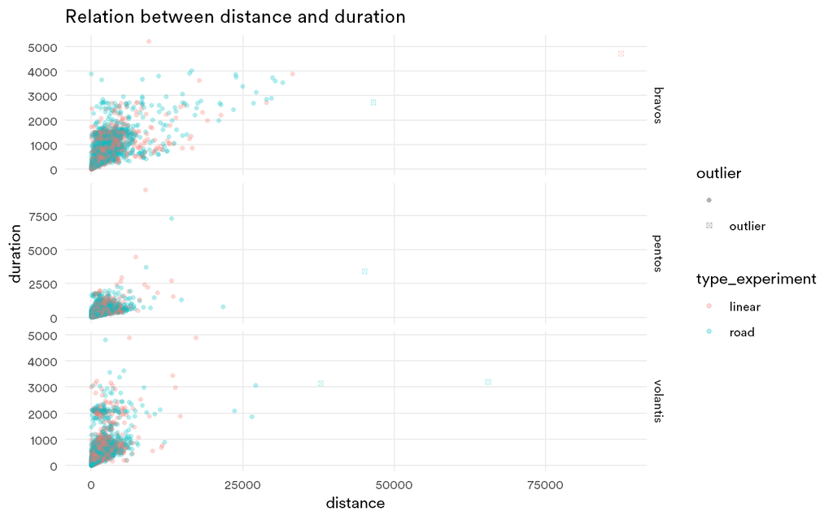

Now, let’s do the sale with metric speed we just calculated. We can compare speed distribution between these two groups, and for each city, mean of distribution is plotted with dotted lines:

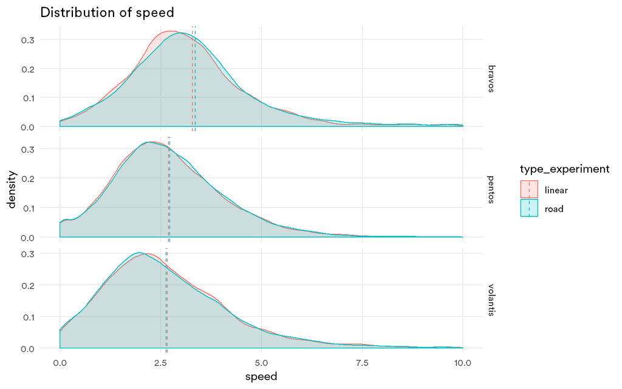

We can appreciate that for bravos and pentos, *road* distance performs slightly better, but for volantis it is the opposite.

We can compute the means and see the exact values:

| city_id | linear | road |
| --- | --- | --- |
| bravos | 3.28 | 3.35 |
| pentos | 2.70 | 2.73 |
| volantis | 2.66 | 2.63 |

#### Hipothesis testing

We run the following hypothesis testing, one for each city:

$$H_0 : \text{speed}_{linear} = \text{speed}_{road} \\
H_A : \text{speed}_{linear} < \text{speed}_{road}$$

And we obtain the following results:

| city_id | p_value | t_value |
| --- | --- | --- |
| bravos | 0.10 | -1.27 |
| pentos | 0.02 | -1.98 |
| volantis | 0.88 | 1.17 |

Let’s start with Pentos. As p-value is lower than 0.05, we can state that the difference is statistically significant.

For Bravos, as the p-value is 0.1, we cannot yield to same conclusion. We have three options here:

- We may be committing a type-II error, failing to reject the null hypothesis. We can run the experiment longer collect more data to increase the power of our test.
- Lower the confidence level to 90% in order to accept the alternative hypothesis.
- Difference observed is not statistically significant.

For Volantis, we saw previously that mean of *road* distance was smaller than *linear*, so we don’t see difference in this city.

#### Conclusions

Let’s jump to the conclusions and answer the questions of this exercise.

First of all, let’s see if company should move towards *road* distance. We have just seen that the difference in speed between *road* and *linear* distance is statistically significant for Pentos, almost for Bravos (we assume we have lowered our confidence level of our analysis) and there is no significant improvement for Volantis.

However, as using *road* distance implies a cost, let’s analyse if it is worth the change in terms of benefit. Some assumptions have been made:

- We base this analysis on means of data provided, but there is only a day and a half of data. More robust conclusions could be extracted with a wider history.
- As a provider of *road* distance, we could use [google maps](https://developers.google.com/maps/documentation/directions/usage-limits). In this case, its cost is $5 / 1000 requests ($4 if usage is heavy).
- We assume a trip only costs $12 regardless of distance, for simplicity.

With this numbers, we can yield that using google API for a high amount of vehicles is very expensive. For example, in Pentos, with more than 3000 vehicles, quering the API for all of them costs as much as the trip itself, so it is not worth it.

However, we can mix both criteria in order to improve the way we measure distance. As it does not make sense to API query for the distance of furthest vehicles, because it is very likely that its *road* distance would be larger than others, we can compute a *composed* distance, based on two steps:

- Compute *linear* distance for all vehicles. Keep only the *n* closest vehicles.
- With API, **only query for these n vehicles**, in order to determine which one will be faster in arriving to rider.

Calculations have been made as following. For each city, we have:

- Computed number of vehicles per day, total number of trips per day and average number of trips per vehicle per day. These calculations have been made only using first complete 24 hours of data
- Calculated mean distance and mean duration of trips (of event `going_to_pickup`)
- Estimated number of seconds of driving to pick up the rider gained with *road* distance per trip, per vehicle a day, and per day of whole city. We make the assumption that this time is used to new trips, so we can compute how many new trips could be made by vehicle with this time.
- Computed how much would it cost a query with *road* API for **the 5% closest vehicles** in terms of linear distance.
- Calculated benefit obtained with *linear* distance (no API required, but less trips) and with *road* distance.

| city_id | number_vehicles | number_trips_per_day | mean_trips_per_vehicle | mean_speed_linear | mean_speed_road | difference_mean_speed | mean_distance | mean_duration | seconds_gained_per_trip | seconds_gained_per_vehicle | trips_gained_per_vehicle | trips_gained_per_day | cost_per_query_n_vehicles | benefit_road | benefit_linear |
| --- | --- | --- | --- | --- | --- | --- | --- | --- | --- | --- | --- | --- | --- | --- | --- |
| bravos | 200 | 3551 | 17.75 | 3.28 | 3.35 | 0.07 | 2107.01 | 650.89 | 151.50 | 2689.84 | 4.13 | 826.52 | $0.05 | $52,311.33 | $42,612.00 |
| pentos | 3203 | 22876 | 7.14 | 2.70 | 2.73 | 0.03 | 711.66 | 260.89 | 21.48 | 153.45 | 0.59 | 1883.86 | $0.80 | $277,186.64 | $274,512.00 |
| volantis | 823 | 8048 | 9.78 | 2.66 | 2.63 |  | 868.47 | 338.46 |  |  |  |  | $0.21 |  | $96,576.00 |

For example, for Bravos, with a small number of vehicles, benefit of changing to *road* distance would be $9,699 more than *linear*, and $2,675 for Pentos.

To see which is maximum cost per query that we could afford in order to get more benefits, we can simulate different scenarios:

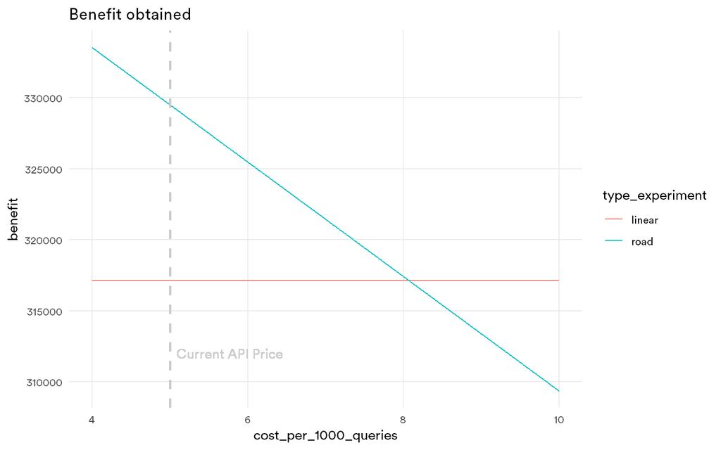

And we can see that we can afford until $8.07 per 1000 queries with this assumptions.

#### Next steps

To improve the experimental design, I would collect data for a longer period (a week would be better, in order to measure if *road* distance performs better even on weekends), and I would add more information to the analysis. For example, district zone where trip was requested. With this information, we could narrow our analysis and check if *road* distance is better in the center of the city rather than in the suburbs.

Besides, other analyses could be made in order to determine how many closest vehicles do we need to query with *road* distance, as maybe 5% vehicles for big cities like Pentos is too much, and we can get similar results with less vehicles.